# PROJET MACHINE LEARNING

Marlène CHEVALIER et Olga SILVA

Juillet 2020

# Sujet d’étude : succès d’une campagne marketing

L’analyse porte sur une campagne marketing conduite auprès d’un ensemble de clients résidant en France. Sur chaque client, le résultat de la campagne est mesurée par sa “réussite (success)” ou son “échec (failure)”.

**L’objectif du projet consiste à prédire le succès de la campagne marketing en fonction des caractéristiques des clients**

## Jeu de données

Pour cela, nous disposons de 2 fichiers qui, pour chaque ligne d’un ﬁchier, décrit un client.

- le fichier d’apprentissage/d’entainement (10 000 clients et 12 variables) : **projet-app-13-learn.csv**
- le fichier test (10 000 clients et 11 variables) : **projet-app-13-test.csv**

Les variables caractérisant chaque client sont les suivantes :

- **age** : âge du client
- **sex** : genre du client
- **f_name** : prénom du client
- **last name** : nom du client
- **commune** : nom de la commune de résidence du client  
  (Lyon, Paris et Marseille sont découpées en arrondissements et que le nom de commune est alors celui de la ville suivi de l’indication d’arrondissement)
- **insee code** : code insee de la commune de résidence
- **city type** : type de la commune de résidence
- **department** : numéro du département de résidence
- **reg** : code de la région de résidence
- **catégorie** : code de la catégorie socio-professionnelle du client
- **revenu** : salaire mensuel en équivalent temps plein
- **cible** : résultat de la campagne codé par “success” pour un résultat considéré comme positif et “failure” dans le cas contraire. Cette variable est absente du fichier test.

## Données complémentaires

Des informations annexes peuvent être utilisées pour cette analyse :

- la **table des catégories socio-professionnelles** associe le code et le nom de chaque catégorie
- le fichier **cities-gps.csv** contient les coordonnées géographiques des villes de métropole, identifiées par leur code insee
- le fichier **cities-population.csv** contient la population de chaque ville de métropole
- le fichier **departments.csv** contient l’association entre le numéro de département et son nom, ainsi que la région dans laquelle chaque département est situé
- le fichier **regions.csv** contient l’association entre le numéro de région et son nom

# Préparation des données

## Chargement des données et préparation des variables

**Retraitements nécessaires :**

- Nous allons renommer la variable catégorie, pour enlever l’accent : *catégorie* devient *categorie*
- Certaines variables numériques sont à interpréter comme des codes, nous les convertissons en facteur : *reg* et *categorie*.
- Nous convertissons la variable cible en variable logique : “failure” devient FALSE et “success” devient TRUE

**Compléter avec les données géographiques :**

Nous ajoutons les coordonnées géographiques et la population aux jeux de données d’entrainement et de test.

## Traitement des données manquantes

### Recencement des données manquantes

**Jeu d’appprentisage**

Dans le jeu d’apprentissage, seule la variable “revenue” est manquante pour 5320 valeurs, soit 53% de valeurs manquantes.

Le graphique suivant confirme cette observation :

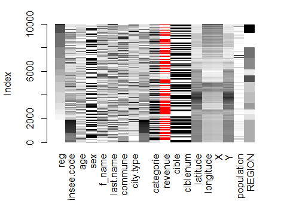

**Jeu de test**

Dans le jeu test aussi, seule la variable “revenue” est manquante pour 5175 valeurs, soit 52% de valeurs manquantes.

### Résultat de campagne et revenus manquants

Regardons s’il y a un lien entre le résultat de la campagne et les revenus manquants.

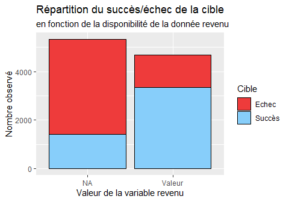

Graphiquement, nous voyons que la proportion d’échec de la campagne est plus importante lorsque la variable “revenu” n’est pas renseignée. Nous pouvons donc faire l’hypothèse qu’il y a un lien entre l’echec de la campagne et le fait d’avoir des revenus manquants.

### Identifier la cause des revenus manquants et l’influence sur le résultat de la campagne

Créons une variable qui dépend de la disponibilité ou non (NA) de la variable revenu et du succès ou de l’échec de la campagne (variable cible). Cette nouvelle variable *revmv.cible* prend donc les valeurs :

| Variable Revenu | Cible = Succès | Cible = Echec |
| --- | --- | --- |
| Valeur numérique | **revVAL-succès** | **revVAL-échec** |
| NA | **revNA-succès** | **revNA-échec** |

Cherchons s’il se dégage une influence marquée, entre cette variable composée et une des covariables de notre jeu de données : l’âge, la catégorie socio-professionnelle, le genre, la région ou le type de ville.

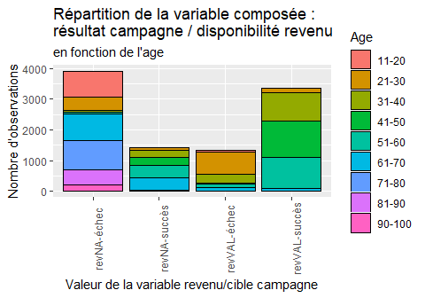

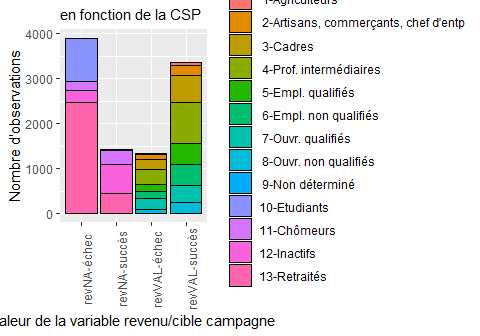

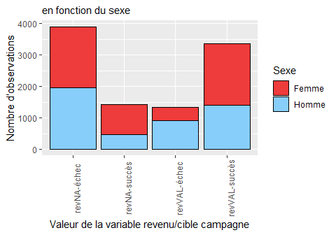

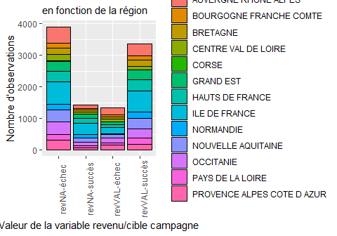

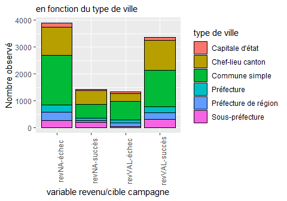

Il apparait que les valeurs du genre, de la région ou du type de ville sont représentées indifféremment que le revenu soit manquant ou non.

**L’âge** présente une particularité : les personnes de plus de 70 ans et, à forte majorité, celles de moins de 20 ans n’ont pas indiqué leur revenu et ne sont pas la cible de la campagne.

**La catégorie socio-professionnelle** est corrélée à l’absence d’indication de revenu. En effet, il apparait que les étudiants, les chômeurs, les inactifs et les retraités soient les seuls à ne pas avoir renseigné leur revenu.

**Les valeurs manquantes du revenu viennent donc exclusivement de 4 CSP , 10 Etudiants - 11 Chômeurs - 12 Inactifs et 13 Retraités, et concernent essentiellement les - de 20 ans et les + de 70 ans**

# Analyse exploratoire des données

Regardons maintenant graphiquement les **principales particularités du jeu de données d’apprentissage.**

## Équilibre dans le jeu de données

Une de première étapes d’analyse exploratoire de données est de vérifier que le jeu de données est équilibré.

Sur l’ensemble de la population d’apprentissage :

- la majorité des individus, soit 5221, sont une **cible “échec” de la campagne, soit 52%** de cette population.*
- 4779 individus sont associés à une **campagne réussie, soit 48% de cette population.**

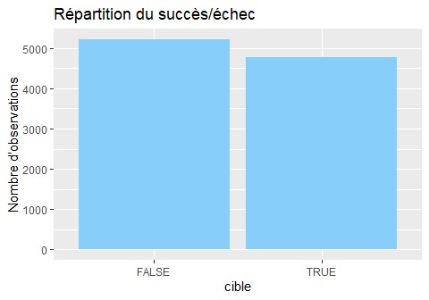

Cela veut dire que notre jeu de données et équilibré, donc, nous n’avons pas besoin d’appliquer des techniques de sous-échantillonnage ou SMOTE par exemple.

## Résultat de la campagne selon le sexe des personnes interrogées

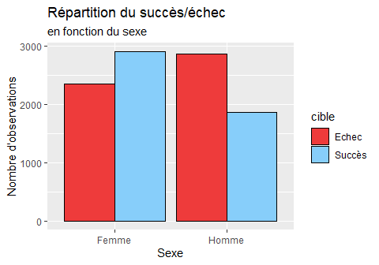

L’ensemble d’apprentissage comporte 5259 femmes (53% ) et 4741 hommes (47% ), soit un écart entre les femmes et les hommes supérieur à la situation nationale (la population globale française comprend 6% de plus de femmes seulement).

Le taux de réussite de la campagne chez les femmes de

[output not shown]

% est plus important que chez les hommes

[output not shown]

%.

**Les femmes ressortent donc majoritairement en réussite sur la cible de la campagne alors que les hommes sont à l’inverse majoritairement en échec.**

## Résultat de la campagne selon l’age des personnes interrogées

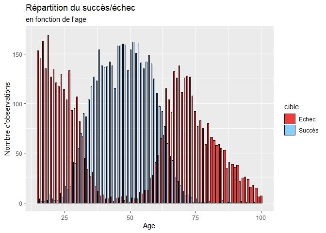

La courbe du nombre d’observations de réussite de la campagne forme une cloche entre 25 ans et 74 ans : pour les 40-55 ans, la campagne est quasi-totalement une réussite (haut de la cloche) ; alors que pour les populations les plus jeunes (avant 25 ans) et les plus agées (après 74 ans), l’échec sur la campagne est quasi-général.

**Le résultat de campagne est fortement déterminé par l’age de la personne interrogée**

## Résultat de la campagne selon la catégorie socio-professionnelle des personnes interrogées

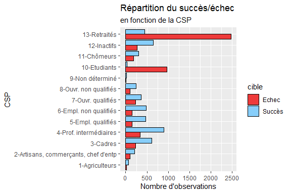

Les catégories socio-professionnelles les plus représentées dans cette étude sont les retraités (à presque 30%), puis les professions intermédiaires (12%), les étudiants(10%) et inactifs (9%) ; les plus faiblement représentés sont les agriculteurs (1,5%).  
Les catégories socio-professionnelles présentent toutes une majorité de succès, sauf les étudiants et les retraités, ce qui se rapprochent des résultats de la campagne par age (ci-dessus).

## Résultat de la campagne selon le type de ville

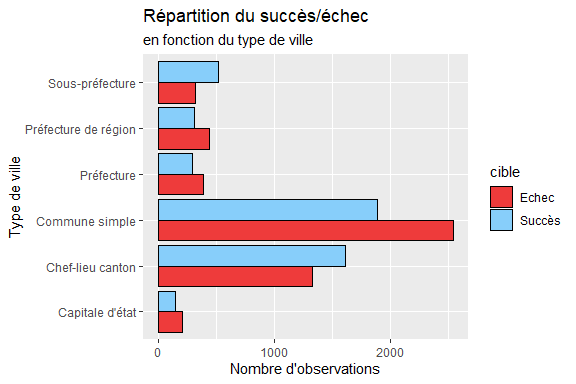

Le type de ville principalement interrogées sont les communes simples et les chefs lieu de canton (73% des réponses). Les échecs de la campagne sont majoritaires dans tous les types de ville sauf 2 : les sous-préfectures et les chefs-lieux de canton.

## Résultat de la campagne selon les régions

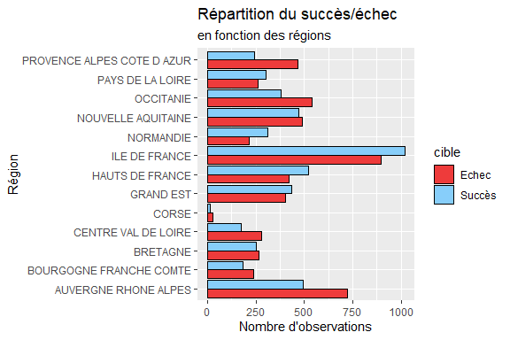

Les régions dans lesquelles le plus de personnes ont été interrogées sont l’Ile de France (où le succès l’emporte) et l’Auvergne Rhône Alpes (où l’échec l’emporte).

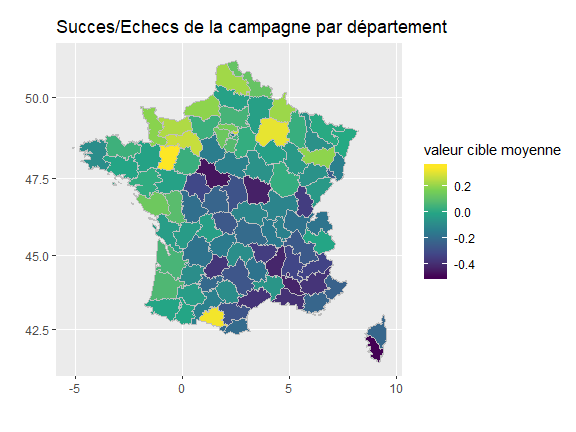

Sur cette carte, on a attribué la valeur “1” aux individus pour lesquels la campagne est un succès et la valeur “-1” en cas d’échec. La valeur cible moyenne est la moyenne des valeurs cible (1 et -1) sur l’ensemble des personnes interrogées du département.

On retrouve sur la carte **les zones de succès (valeur moyenne cible >0) au Nord et à l’Ouest ; et du centre au quart sud Est, les régions enregistent majoritairement des échecs.**  
(3 départements à fort succès : Mayenne, Ariège et Marne / 3 départements à fort échecs : Corse du Sud, Loire et Cher, Nièvre).

## Récapitulatif de l’analyse exploratoire : caractéristiques des résultats de la campagne

| Succès = 48% : sont plutôt | Echec = 52% : sont plutôt |
| --- | --- |
| des femmes | des hommes |
| entre 40 et 55 ans | - de 25 ans ou + de 70 ans |
| professions intermédiaires, inactifs, cadres | étudiants, retraités |
| résidents du quart Nord-ouest | résidents du Centre au quart Sud-Est |

# Ajustement des modèles

Il s’agit, d’une part, de construire le modèle de prédiction de la cible de campagne, en testant plusieurs méthodes (régression logistique, arbre de decision, random forests, boosting), d’évaluer les performances des modèles en calculant le taux d’erreur entre les prévisions et les vraies valeurs, en analysant la courbe de ROC. D’autre part, on tentera d’identifier les variables les plus influentes pour la détermination de la prédiction (importance des variables).

## Régression logistique

**Validation croisée**

Nous créons d’abord la partition de données, avec 70% pour l’entrainement et 30% pour la validation.  
Nous excluons les variables de type identifiant et avec trop de modalités, pour éviter de bloquer les algorithmes (insee.code, f_name,last.name, commune, départment, latitude, longitude, X, Y, reg) et la variable revenu qui contient des valeurs manquantes.

Ensuite nous utilisons la fonction GLM, pour faire une régression logistique. Voici le modèle que la fonction step a choisi comme le meilleur (le minimum AIC)

```
glm(formula = cible ~ categorie + age + sex + REGION + city.type,
    family = binomial(logit), data = train)
```

Avec un AIC de (5832.4). Il semblerait dans ce choix que la variable “population” ne soit pas pertinent.

**Prédiction**

Voici la matrice de confusion quand le seuil est fait à 50% :

```
        FALSE TRUE
  FALSE  1243  208
  TRUE    323 1225
```

L’erreur de prédiction que nous obtenons est de :17.71 %

Nous pouvons optimiser cette prédiction, en trouvant le seuil optimal :59.03 %. La matrice de confusion devient :

```
        FALSE TRUE
  FALSE  1343  279
  TRUE    223 1154
[1] 16.74
```

La matrice de confusion :  
1343, 223, 279, 1154

La nouvelle erreur de prédiction est plus basse : 16.74 % .  
L’accuracy de 83.26 %.

**Ajustement du modèle**

Graphique des résidus

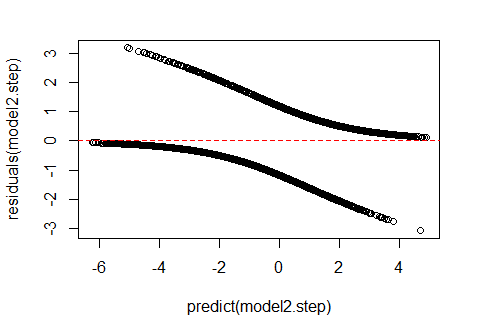

**Courbe de ROC et AUC** :

Comme dernière étape, nous allons construire la courbe ROC et calculer l’AUC (area under the curve), qui sont des mesures de performance. La courbe ROC est la représentation des TPR (True positive rate, “Vrais positifs”) en fonction des FPR (False positive rate, “Faux positifs”), selon plusieurs seuils. La courbe de ROC doit être au-dessus de la première bissectrice. Plus la courbe ROC de l’algorithme tend vers 1 (100%) rapidement, meilleure est la qualité de la prédiction.

L’AUC est l’aire sous la courbe ROC. Elle doit être comprise entre 0.5 et 1 (seuil AUC donnant la meilleure qualité de la prédiction).

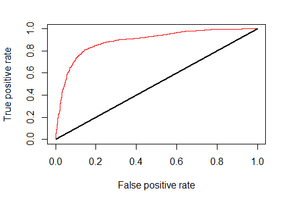

**Avec un modèle GLM, on obtient un AUC de 0.8895.**

## Arbres de décision

Nous utilisons la fonction **rpart** pour construire l’arbre de décision.

**Validation croisée**

**Création du premier arbre**

Nous allons faire notre premier arbre sans ajuster les paramêtres de contrôle de l’arbre, avec les paramètres par défaut de la fonction rpart (minsplit = 20, minbucket = round(minsplit/3), cp = 0.01)

Voici le graphique de l’arbre qui est produit avec rpart:

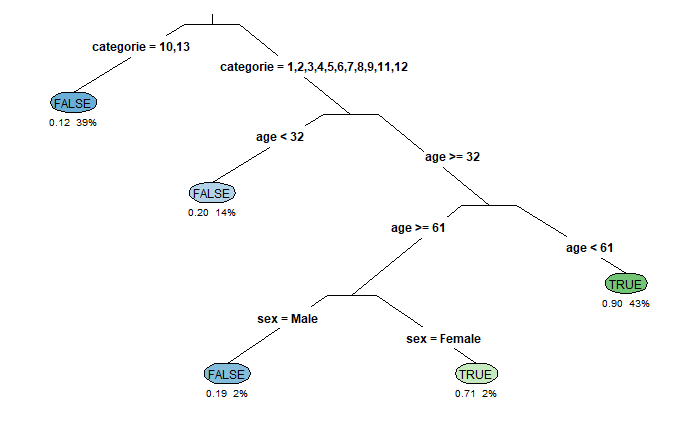

**rpart** utilise l’impureté Gini pour sélectionner les divisions lors de la classification. L’impureté Gini est la probabilité de classer incorrectement un élément choisi au hasard dans l’ensemble de données, s’il était étiqueté de manière aléatoire en fonction de la distribution des classes. Si l’impureté Gini est à 0 , cela signifie que les données sont dans la même classe.

Sans surprise, comme nous l’avions vu dans l’analyse exploratoire, la CSP, l’âge et le genre sont les critères utilisés pour faire les splits. Les catégories 10 et 13 font le premier split, ensuite l’âge 32 et 61, pour finir avec le genre. Aucune autre variable n’est utilisée pour faire des splits.

Avec ce graphique, chaque noeud montre :

- La classe prédite (TRUE ou FALSE)
- La probabilité d’être VRAI
- Pourcentage d’observations dans chaque noeud

**Zoom sur le CP**

Le CP (complexity parameter) est utilisé pour contrôler la croissance de l’arbre et sélectionner la taille optimale de l’arbre. Si le coût d’ajouter une variable est plus élevé que la valeur du CP, la croissance s’arrête.

Les fonctions **printcp** et **plotcp** fournissent l’erreur de validation croisée pour chaque nsplit et peuvent être utilisées pour élaguer l’arbre. Celui avec le moins d’erreur de validation croisée (xerror) est la valeur optimale de CP.

Avec **plotcp**, il vous montre également l’endroit optimal pour élaguer l’arbre. Un bon choix de CP pour l’élagage est souvent la valeur la plus à gauche pour laquelle la moyenne se situe en dessous de la ligne horizontale, dans notre cas 0,01, la valeur par défaut.

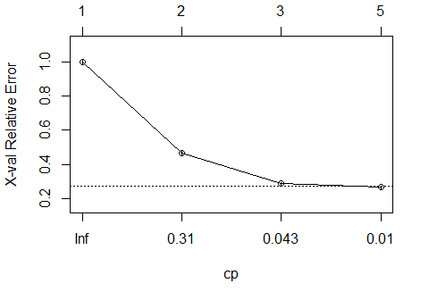

Pour la fonction **printcp**, chaque ligne représente une hauteur différente de l’arbre. En général, plus de niveaux dans l’arbre signifient qu’il a moins d’erreur de classification sur l’entrainement. Cependant, il existe le risque d’overfitting. Souvent, l’erreur de validation croisée augmentera à mesure que l’arbre atteindra plus de niveaux (au moins, après le niveau «optimal»).

```
Classification tree:
rpart(formula = cible ~ ., data = train_arbre, method = "class")

Variables actually used in tree construction:
[1] age       categorie sex

Root node error: 3346/7001 = 0.47793

n= 7001

        CP nsplit rel error  xerror      xstd
1 0.533473      0   1.00000 1.00000 0.0124911
2 0.182905      1   0.46653 0.46653 0.0104087
3 0.010012      2   0.28362 0.28661 0.0085979
4 0.010000      4   0.26360 0.26569 0.0083260
```

Dans notre cas ce valeur est 0,01.

**Matrice de confusion et ROC**

La matrice de confusion :  
1426, 140, 226, 1207

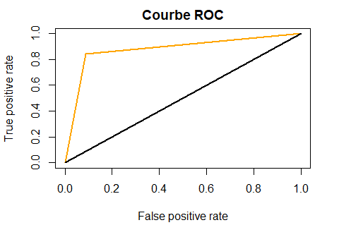

La courbe ROC pour l’arbre de décision atteint très rapidement la valeur de 0,8, plus rapidement que la courbe ROC pour la régression logistique.

**Avec un modèle d’arbre de décision, on obtient un AUC de 0.8764**

**Tuner l’arbre**

Nous allons modifier le paramètre “minsplit”, il contrôle le nombre minimum d’observations qui doit exister dans un nœud pour qu’une tentative de division soit faite; nous allons aussi modifier la valeur CP pour augmenter la croissance de l’arbre de décision.

Nous allons démarrer avec le CP = 0.0001, et minsplit =2, afin d’observer la croissance de l’arbre et les différentes valeurs de CP.

Avec ce nouvel arbre, nous obtenons des meilleurs résultats (selon la matrice de confusion), cependant c’est possible qu’il soit surajusté aux valeurs de l’entrainement et qu’il fonctionnement mal avec les données de tests. Nous devons maintenant élaguer notre arbre.

```
tree.pred2 FALSE TRUE
     FALSE  1460   97
     TRUE    106 1336
```

La matrice de confusion :  
1460, 106, 97, 1336

**Elaguer l’arbre**

Pour cette étape nous allons utiliser la fonction printcp, et avec le valeur le plus bas de xerror (cross-validated error) nous trouverons la valeur optimal de CP.

```
Classification tree:
rpart(formula = cible ~ ., data = train_arbre, method = "class",
    control = rpart.control(minsplit = 2, cp = 1e-04))

Variables actually used in tree construction:
[1] age        categorie  city.type  population reg        revenue    sex

Root node error: 3346/7001 = 0.47793

n= 7001

           CP nsplit rel error  xerror      xstd
1  0.53347280      0  1.000000 1.00000 0.0124911
2  0.18290496      1  0.466527 0.46653 0.0104087
3  0.01001195      2  0.283622 0.28631 0.0085942
```

[output cut: 31 more lines]

Toutes les variables ont été utilisées pour la construction du nouvel arbre, c’est-à-dire : age, categorie, city.type, population, reg, revenue et sex.

À partir de cette table des différentes valeurs de CP nous pouvons trouver la valeur optimale :

**La valeur optimale de CP est 3.9848575^{-4}**, avec un **xerror de 0.12343**.  
Dans le graphique suivant on observe bien la diminution de xerror qui atteint son minimum et ensuite remonte à nouveau.

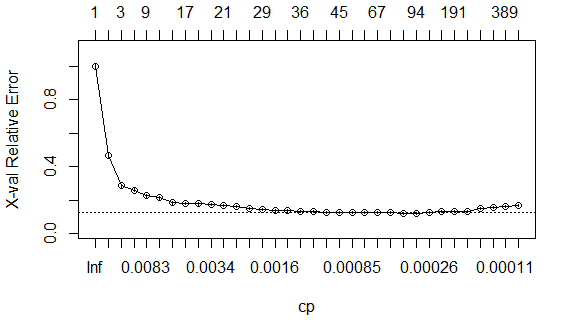

Maintenant nous pouvons élaguer l’arbre avec la valeur optimale de CP.

Voici notre nouvelle matrice de confusion, avec le CP optimal :

```
tree.pred3 FALSE TRUE
     FALSE  1484   82
     TRUE     82 1351
```

1484, 82, 82, 1351

**Importance des variables**

Nous allons obtenir l’importance des variables pour faire les splits de l’arbre de décision. L’importance des variables explicatives selon le critère de Gini signifie que : plus le critère est haut, plus la variable aura de l’influence pour distinguer le succès de l’échec de la campagne.

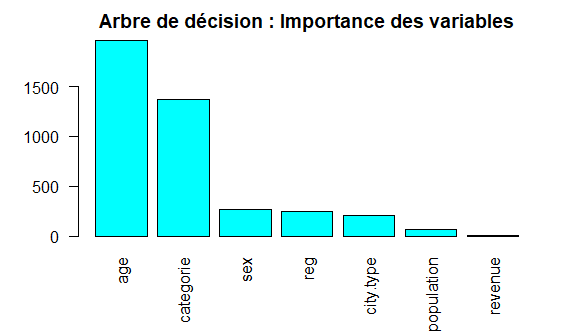

Ce résultat graphique coincide avec ce que nous avons observé lors de l’analyse exploratoire : l’âge et la catégorie sont les variables les plus pertinentes pour effectuer la prediction de la cible.

**ROC et AUC**

Voici la courbe ROC pour ce dernier arbre de décision :

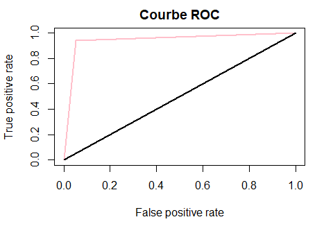

**Après avoir tuné l’arbre, on obtient un AUC est de 0.9452**

## Méthode ensembliste : Random Forest

La méthode repose sur l’apprentissage du modèle prédiction sur plusieurs arbres. Les différentes prédictions sont comparées selon leur qualité et une seule d’entre elles est retenue par vote majoritaire.  
La fonction utilisée est **randomForest**.

Nous reprenons les ensembles d’entrainement et de validation déjà utilisés pour les arbres de décision.

**Paramètres optimaux de la forêt aléatoire**

Les parametres d’une foret aléatoire sont le nombre d’arbres (ntree) et le nombre de variables explicatives testées à chaque séparation (mtry). Pour les optimiser, il faut chercher le modèle de forest aléatoire qui minimise l’erreur Out Of Bag.

Nous commençons par ne pas fixer ces paramètres.

La forêt aléatoire choisie de façon standard contient 500 arbres et teste 2 variables à chaque séparation. On obtient le résultat suivant :

```
Call:
 randomForest(formula = cible ~ ., data = train_arbre, na.action = na.omit)
               Type of random forest: classification
                     Number of trees: 500
No. of variables tried at each split: 2

        OOB estimate of  error rate: 7.28%
Confusion matrix:
    0    1 class.error
0 745  181  0.19546436
1  57 2284  0.02434857
```

L’erreur d’estimation se mesure ici par le taux d’erreur Out of Bag (OOB) : il s’agit de l’erreur d’estimation moyenne sur les échantillons d’apprentissage. Nous cherchons maintenant à optimiser la taille de la foret (nombre d’arbres), c’est à dire trouver la taille qui permettra de réduire l’erreur OOB.

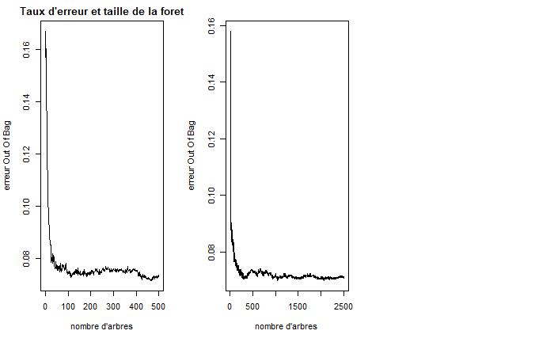

| Nombre d’arbres (ntree) | taux d’erreur Out of Bag |
| --- | --- |
| 500 | 7.28 |
| 2500 | 7.07 |
| 3500 | 7.28 |
| 5000 | 7.38 |

```
Call:
 randomForest(formula = cible ~ ., data = train_arbre, ntree = 5000,      mtry = 4, na.action = na.omit)
               Type of random forest: classification
                     Number of trees: 5000
No. of variables tried at each split: 4

        OOB estimate of  error rate: 6.83%
Confusion matrix:
    0    1 class.error
0 773  153  0.16522678
1  70 2271  0.02990175
```

| Nombre de var. (mtry ) | taux d’erreur Out of Bag |
| --- | --- |
| 1 | 11.33 |
| 2 | 7.38 |
| 4 | 6.83 |
| 6 | 6.86 |

```
Call:
 randomForest(formula = cible ~ ., data = train_arbre, ntree = 5000,      mtry = 4, na.action = na.omit)
               Type of random forest: classification
                     Number of trees: 5000
No. of variables tried at each split: 4

        OOB estimate of  error rate: 6.83%
Confusion matrix:
    0    1 class.error
0 773  153  0.16522678
1  70 2271  0.02990175
```

**Importance des variables**

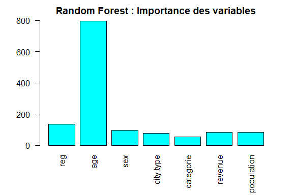

**ROC et AUC**

La matrice de confusion :

```
rforest6.pred   0   1
            0 339  20
            1  62 992
```

339, 62, 20, 992

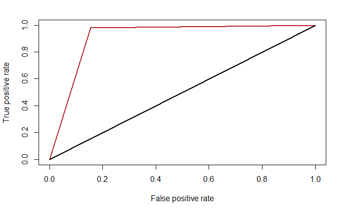

**Avec un modèle de forêt aléatoire, on obtient un AUC est de 0.9128**

Ici on observe que, selon le critère de Gini, l’age est la variable la plus discriminante.

## Méthode ensembliste : le boosting - XGBOOST

Une autre méthode que nous pouvons utiliser est le XGBOOST (Extreme Gradient Boosting) ; c’est une méthode similaire au gradient boosting mais plus efficace. Elle combine des algorithmes d’apprentissage des arbres et des modèles linéaires. En plus, elle permet de faire des calculs parallèles sur une seule machine, ce qui la rend très rapide.

Avec cette méthode nous pouvons faire des régressions, classifications et rankings. Cependant il y a plusieurs paramètres qui doivent être contrôlés afin d’optimiser le modèle.

**Préparation des données**

Avant d’utiliser l’algorithme xgboost nous devons preparer les données, XGBoost fonctionne uniquement avec des vecteurs numériques. C’est-à-dire, nous devons transformer toutes nos variables utiliser en nombre, dont sex, categorie, reg et city.type.

1- Transformation des Variables vecteurs numériques

```
Classes ‘data.table’ and 'data.frame':  7001 obs. of  3 variables:
 $ age       : int  35 65 74 28 57 39 18 44 68 57 ...
 $ revenue   : num  1900 NA NA 1800 2360 1810 NA 1870 NA 1310 ...
 $ population: int  32158 52264 52264 2361 3054 37412 37412 26396 26396 1574 ...
 - attr(*, ".internal.selfref")=<externalptr>
```

Nous allons utiliser le one hot encoding pour créer des variables “dummy” et ainsi convertir les variables en numériques. Par exemple, pour le genre il fera deux variables : SexFemale et SexMale, et donnera la valeur de 1 sur la colonne SexFemale quand l’individu est de sexe féminin et zéro dans la colonne SexMale.

2 - Séparer la variable à prédire

La deuxième étape consiste à séparer la variable cible du reste de la matrice.

3 - Dmatrice

La troisième étape consiste à convertir nos données en format Dmatrice. Cette étape n’est pas nécessaire, mais elle va faire que l’entrainement soit plus rapide, et c’est obligatoire si on souhaite utiliser plusieurs coeurs. Nous utilisons pour le faire la fonction xgb.DMatrix.

**Entrainer le modèle**

Afin d’entrainer notre modèle, Xgboost a besoin de connaître :

1- Les données à utiliser pour l’entrainement, notre dmatrix dtrain 2- Le nombre de tours d’entrainement. Cela signifie le nombre de fois où nous allons améliorer notre modèle en ajoutant des modèles supplémentaires. 3- La fonction objective. Nous allons utiliser “binary:logistic”, qui est la régression logistique pour la classification binaire. Par défaut, xgboost effectue une régression linéaire.

**Graphique de l’arbre**

**Prédiction avec xgboost**

Nous pouvons maintenant lancer notre entrainement avec la fonction classique *predict*.

```
[1] "erreur de test = 7.336 %"
```

**Matrice de confusion**

Regardons maintenant la matrice de confusion:

```
          ts_label
pred_label    0    1
         0 1432   86
         1  134 1347
```

**Améliorer notre modèle**

Nous pouvons modifier quelques paramètres pour améliorer notre modèle :

- **max.depth** = 6 la profondeur maximale de chaque arbre de décision
- **nrounds** = 100 nombre maximum d’itérations de boost

```
[1] "erreur de test = 5.068 %"
```

Uniquement avec des deux paramètres, notre erreur a baissé. Cependant nous avons d’autres paramètres qui peuvent être ajustés, comme :

- **eta** = Taille de chaque étape de boosting
- **nfold** = l’ensemble de données d’origine est partitionné de manière aléatoire en nfold sous-échantillons de taille égale
- **nthread**= nombre de threads utilisés dans la formation, s’ils ne sont pas définis, tous les threads sont utilisés

**Importance des variables**

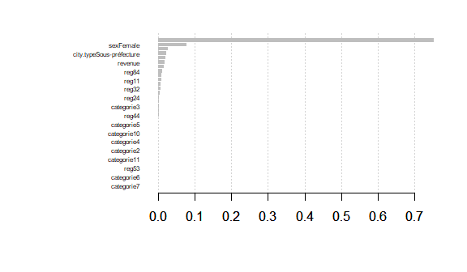

Contrairement aux autres modèles, ici la catégorie et l’âge ne sont pas pertinents, on se base principalement sur le genre.

**Courbe ROC et AUC**

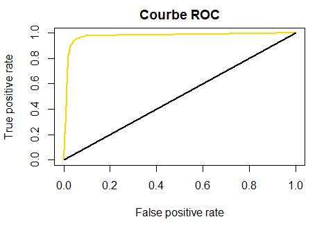

**Avec un modèle de xgboost, on obtient un AUC est de 0.9734**

## En conclusion

Les résultats des différentes méthodes testées sont les suivants :

[output not shown]

**La modélisation de la variable cible par la méthode Xgboost apporte ici le meilleur résultat.**  
En effet, l’AUC du boosting est le plus proche de 1 (0.9734), ce qui s’illustre par une courbe de ROC qui tend le plus rapidement vers 1 (graphiquement: la plus proche du coin supérieur gauche).

# Prédiction

Nous choisissons donc de faire la prédiction à partir du modele de boosting.

# Annexes

## Annexe - Données Manquantes

**Le revenu et l’âge**

Les valeurs des revenus sont observées uniquement sur la tranche d’âge des 18 ans-69 ans, qui correspond à la période d’activité professionnelle.

**Le revenu et la catégorie socio-professionnelle**